# Data Wrangling on Multiple Tables

Jake Rozran

2/23/2022

## What is a Join?

In many cases, we have a dataset that has been intentionally abbreviated or is missing key data for our analysis.

When this happens, we join together datasets (sometimes many datasets, but at least 2) to ensure we can do a complete analysis.

When we “join” data, we are matching a row (or more) from one dataset to a corresponding row (or more) in a second dataset.

For example, perhaps you know how many flights per day there are from NYC area airports and you want to see if the weather on each day affects the departure rate.

Another example, perhaps your dataset abbreviates a specific column (like an airport code or airline name) and another table elaborates on it. You can join the two together to get a complete picture.

## Explaining Joins

There are multiple types of joins. We’ll be focused on Inner Joins and Left Joins, but it is important to understand how they work before we do them.

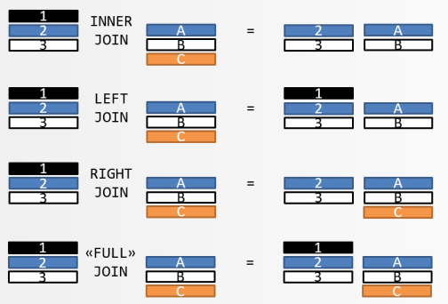

## Inner Joins

Inner joins only return those results from table 1 that are in table 2 and table 2 that are in table one.

In our `flights` data from the homework, we have a `carrier` column. Some of them we can infer - UA is [probably] United Airlines and AA is [probably] American Airlines, but what about B6?

Thankfully, there is another table with `airlines` data.

```r
glimpse(flights)
```

```
## Rows: 336,776
## Columns: 19
## $ year           <int> 2013, 2013, 2013, 2013, 2013, 2013, 2013, 2013, 2013, 2…
## $ month          <int> 1, 1, 1, 1, 1, 1, 1, 1, 1, 1, 1, 1, 1, 1, 1, 1, 1, 1, 1…
## $ day            <int> 1, 1, 1, 1, 1, 1, 1, 1, 1, 1, 1, 1, 1, 1, 1, 1, 1, 1, 1…
## $ dep_time       <int> 517, 533, 542, 544, 554, 554, 555, 557, 557, 558, 558, …
## $ sched_dep_time <int> 515, 529, 540, 545, 600, 558, 600, 600, 600, 600, 600, …
## $ dep_delay      <dbl> 2, 4, 2, -1, -6, -4, -5, -3, -3, -2, -2, -2, -2, -2, -1…
## $ arr_time       <int> 830, 850, 923, 1004, 812, 740, 913, 709, 838, 753, 849,…
## $ sched_arr_time <int> 819, 830, 850, 1022, 837, 728, 854, 723, 846, 745, 851,…
## $ arr_delay      <dbl> 11, 20, 33, -18, -25, 12, 19, -14, -8, 8, -2, -3, 7, -1…
## $ carrier        <chr> "UA", "UA", "AA", "B6", "DL", "UA", "B6", "EV", "B6", "…
## $ flight         <int> 1545, 1714, 1141, 725, 461, 1696, 507, 5708, 79, 301, 4…
## $ tailnum        <chr> "N14228", "N24211", "N619AA", "N804JB", "N668DN", "N394…
## $ origin         <chr> "EWR", "LGA", "JFK", "JFK", "LGA", "EWR", "EWR", "LGA",…
## $ dest           <chr> "IAH", "IAH", "MIA", "BQN", "ATL", "ORD", "FLL", "IAD",…
## $ air_time       <dbl> 227, 227, 160, 183, 116, 150, 158, 53, 140, 138, 149, 1…
## $ distance       <dbl> 1400, 1416, 1089, 1576, 762, 719, 1065, 229, 944, 733, …
## $ hour           <dbl> 5, 5, 5, 5, 6, 5, 6, 6, 6, 6, 6, 6, 6, 6, 6, 5, 6, 6, 6…
## $ minute         <dbl> 15, 29, 40, 45, 0, 58, 0, 0, 0, 0, 0, 0, 0, 0, 0, 59, 0…
## $ time_hour      <dttm> 2013-01-01 05:00:00, 2013-01-01 05:00:00, 2013-01-01 0…
```

```r
head(airlines)
```

```
## # A tibble: 6 × 2
##   carrier name
##   <chr>   <chr>
## 1 9E      Endeavor Air Inc.
## 2 AA      American Airlines Inc.
## 3 AS      Alaska Airlines Inc.
## 4 B6      JetBlue Airways
## 5 DL      Delta Air Lines Inc.
## 6 EV      ExpressJet Airlines Inc.
```

```r
ij_data <- flights %>%
    inner_join(airlines, by = c("carrier" = "carrier")) %>%
    select(tailnum,
           flight,
           carrier,
           name)

nrow(ij_data)
```

```
## [1] 336776
```

```r
nrow(flights)
```

```
## [1] 336776
```

This is lucky, though… Let’s see how it usually is in real life.

```r
incomplete_airlines <- airlines %>%
    head(8)
incomplete_airlines
```

```
## # A tibble: 8 × 2
##   carrier name
##   <chr>   <chr>
## 1 9E      Endeavor Air Inc.
## 2 AA      American Airlines Inc.
## 3 AS      Alaska Airlines Inc.
## 4 B6      JetBlue Airways
## 5 DL      Delta Air Lines Inc.
## 6 EV      ExpressJet Airlines Inc.
## 7 F9      Frontier Airlines Inc.
## 8 FL      AirTran Airways Corporation
```

```r
new_joined_data <- flights %>%
    inner_join(incomplete_airlines, by = c("carrier" = "carrier")) %>%
    select(tailnum,
           flight,
           carrier,
           name)

nrow(new_joined_data)
```

```
## [1] 212766
```

```r
nrow(flights)
```

```
## [1] 336776
```

Now we see that not every row from the flights dataset is included… ONLY those that are in the incomplete_airlines data, too, are included.

## Left Join

Left join will always include all of the rows from table 1, the left dataset. If their isn’t corresponding data in table 2 (the right), it will show up as an NA, not be dropped.

```r
lj_data <- flights %>%
    left_join(airlines, by = c("carrier" = "carrier")) %>%
    select(tailnum,
           flight,
           carrier,
           name)

nrow(lj_data)
```

```
## [1] 336776
```

```r
nrow(flights)
```

```
## [1] 336776
```

```r
lj_data == ij_data
```

[output not shown]

[output cut: 24986 more lines]

Here we see that the `inner_join` and the `left_join` are identical. This is because every row in table 1 matches to a row in table 2. Let’s see what happens when we again use the incomplete dataset.

```r
lj_joined_data <- flights %>%
    left_join(incomplete_airlines, by = c("carrier" = "carrier")) %>%
    select(tailnum,
           flight,
           carrier,
           name)

nrow(lj_joined_data)
```

```
## [1] 336776
```

```r
nrow(flights)
```

```
## [1] 336776
```

```r
head(lj_joined_data)
```

```
## # A tibble: 6 × 4
##   tailnum flight carrier name
##   <chr>    <int> <chr>   <chr>
## 1 N14228    1545 UA      <NA>
## 2 N24211    1714 UA      <NA>
## 3 N619AA    1141 AA      American Airlines Inc.
## 4 N804JB     725 B6      JetBlue Airways
## 5 N668DN     461 DL      Delta Air Lines Inc.
## 6 N39463    1696 UA      <NA>
```

Now we see every row from the flights data is present, but many carrier names are missing.